# IMAP-PART 1 Getting started with Microbiome Data Analysis

Integrated Microbiome Analysis Pipelines (IMAP) with Snakemake & GitHub Actions

Teresia Mrema-Buza

Updated on 2023-02-06

#### Github Repo: https://github.com/tmbuza/imap-requirements.

# General Overview

- We use the snakemake workflow management system<sup>1,2</sup> for:
  - Maintaining reproducibility in technical validation and regeneration of results
  - Creating scalable data analysis scaled to server, grid or cloud environment seamlessly.
  - Fostering sustainable improvement of the microbiome data analysis.
- Reviewing existing workflows methodlogies<sup>2,3</sup> helps in gaining a better insights for improving microbiome data analysis.
- We break any complex workflows into small contiguous but related chunks for simplicity reasons.
- Each major step forms a separate executable snakemake rule and is represented in the DAG (Directed Acyclic Graph).

> We envision to keep fostering on continuous integration and development of highly reproducible workflows.

# Basic requirements

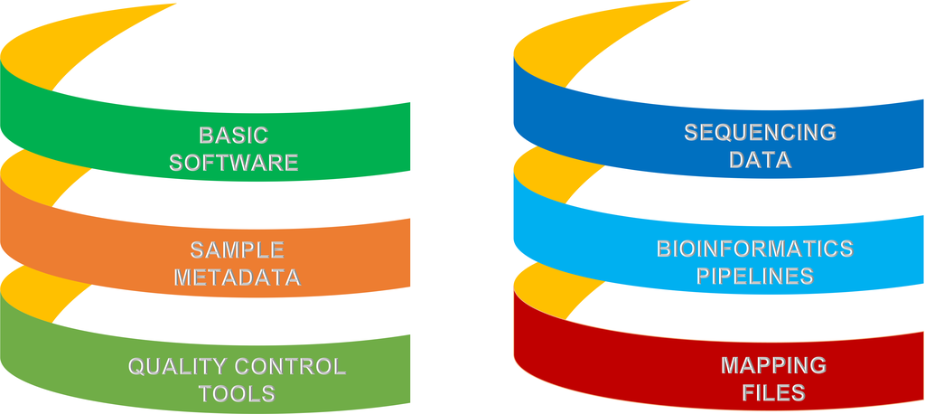

## Snakemake rule DAG

[figure not shown]

## Screenshot of interactive snakemake report

> Open the snakemake html report using a compartible browser such as chrome to explore more on the workflow and the associated statistics. You will be able to close the left bar to get a better view of the dispaly.

[figure not shown]

# Basic Software

## Install R Environment

**R** is a free software for statistical computing, data analysis, and graphics<sup>4</sup>. We need to install R application on a personal computer to process the R programming language. You can download and install R using these steps:

1. Go to https://www.r-project.org/.
2. On the left, under Download, click on [CRAN](http://cran.r-project.org/mirrors.html) to access the mirrors. CRAN (Comprehensive R Archive Network) is mirrored on nearly 100 registered servers in nearly 50 regions world. See [CRAN mirror status](https://cran.r-project.org/mirmon_report.html).
3. https://cloud.r-project.org/ Pick a mirror that is close to your location, and automatically R will connect to that server ready to download the package files.
4. Select a compatible platform to download precompiled binary distributions of the base system, which also come with contributed packages.

## Install RStudio Environment

**RStudio** is a free program that integrates with R as an IDE (Integrated Development Environment) to implement most of the analytical functionalities<sup>5</sup>. For effective analysis, we must install R before installing RStudio. We will intensively use RStudio IDE to give us a user interface. We are interested in **RStudio Desktop**, which is the open-source regular desktop application. You can install it like this:

1. Go to https://rstudio.com/products/rstudio/.
2. Click on [RStudio Desktop](https://rstudio.com/products/rstudio/#rstudio-desktop) box to move to the open source edition.
3. Choose your preferred [license](https://rstudio.com/products/rstudio/download/) either open source or commercial.
4. Select [installer](https://rstudio.com/products/rstudio/download/#download) compatible to your operating system.

[figure not shown]

Screen shot of RStudio User Interface

## Install R packages

- [CRAN](https://cran.r-project.org/) (Comprehensive R Archive Network): The official repository. Reviewed!
- [Bioconductor](https://www.bioconductor.org/): Most popular repository for bioinformatics software. Reviewed!
- [Github](https://github.com/): Most popular repository for open source projects. Not Reviewed!

### Installing and loading packages from CRAN

```
install.packages("packagename")
library("packagename")
```

### Installing and loading R packages from Bioconductor

```
if (!requireNamespace("BiocManager", quietly = TRUE)) install.packages("BiocManager")
library("BiocManager")

BiocManager::install("packagename")}
library("packagename")
```

### Installing and loading R packages from GitHub

```
install.packages("devtools")
library(devtools)

devtools::install_github("r-lib/devtools")
library(devtools)

devtools::install_github("githubID/packagename")
library("packagename")
```

### Show basic package information

```
help("packagename")

or

?packagename

help(package = "packagename")
```

### Get a general overview

```
help(functionname)

or

help(functionname, package = "packagename")
```

### Remove unneeded packages from your computer

```
remove.packages("packagename")
```

### Unload a package

```
detach("package::packagename")
```

### Citing R, RStudio or a package

```
citation()

library(rstudioapi)
versionInfo()$citation

citation("tidyverse")
```

## Useful links

1. R Packages: https://www.datacamp.com/community/tutorials/r-packages-guide.
2. Search CRAN, Bioconductor and GitHub packages and functions: https://www.rdocumentation.org/.

# Sample metadata

## What is metadata?

- **Metadata** is a set of data that describes and provides information about other data. It is commonly defined as **data about data**.
- **Sample metadata** described in this book refers to the description and context of the individual sample collected for a specific microbiome study.

## Embedded metadata

- In most cases, you will find the metadata detached from the experimental data.
- Embedded metadata integrates the experimental data especially for graphics.
- Major microbiome analysis platforms require sample metadata, commonly referred to as **mapping file** when performing downstream analysis.

## Downloading metadata from NCBI-SRA

Typically, after sequencing the microbiome DNA, the investigators are encouraged to deposit the sequence reads in a public repository. The Sequence Read Archive (SRA) is currently the best bioinformatics database for read information. The good thing about SRA is that it integrates data from the NCBI, the European Bioinformatics Institute (EBI), and the DNA Data Bank of Japan (DDBJ).

## Sample distribution

This demo uses metadata associated with the bushmeat microbiome bioproject number [PRJNA477349](https://www.ncbi.nlm.nih.gov/sra?linkname=bioproject_sra_all&from_uid=477349). The metadata and the `run` accessions are available via the [SRA database](https://www.ncbi.nlm.nih.gov/Traces/study/?WebEnv=MCID_63d94ddd2805b915ba189567&query_key=1&GALAXY_URL=https%3A%2F%2Fusegalaxy.org%2Ftool_runner%3Ftool_id%3Dsra_source).

## Read count distribution

[figure not shown]

## Read ascending size

```
# A tibble: 6 × 3
  isolate    ecosystem milionbases
  <chr>      <chr>           <dbl>
1 Warthog    Serengeti           8
2 Porcupine  Serengeti          22
3 Wildebeest Selous             28
4 Giraffe    Serengeti          45
5 Rabbit     Serengeti          54
6 Gazelle    Serengeti          65
```

## Read descending size

```
# A tibble: 6 × 3
  isolate    ecosystem milionbases
  <chr>      <chr>           <dbl>
1 Wildebeest Serengeti        3821
2 Dikdik     Ruaha            3533
3 Cattle     Selous           1276
4 Buffalo    Serengeti         935
5 Impala     Selous            921
6 Hare       Selous            698
```

# Appendix

## Project directories

```
.
├── LICENSE
├── README.md
├── config
│   ├── SraRunTable.csv
│   ├── config.yaml
│   ├── samples.csv
│   └── units.tsv
├── dags
│   ├── dag.png
│   ├── dag.svg
│   ├── rulegraph.png
│   └── rulegraph.svg
├── data
│   ├── metadata
│   └── reads
├── images
│   ├── RStudioIDE.png
│   ├── cicd.png
│   └── imap-part1.png
├── imap-requirements.Rproj
├── index.Rmd
├── library
│   ├── apa.csl
│   └── references.bib
├── project_tree.txt
├── styles.css
└── workflow
    ├── Snakefile
    ├── envs
    ├── rules
    ├── schemas
    └── scripts

12 directories, 20 files
```

## Troubleshooting (in progress)

.

## References

1. Köster, J., Mölder, F., Jablonski, K. P., Letcher, B., Hall, M. B., Tomkins-Tinch, C. H., Sochat, V., Forster, J., Lee, S., Twardziok, S. O., Kanitz, A., Wilm, A., Holtgrewe, M., Rahmann, S., & Nahnsen, S. (2021). Sustainable data analysis with snakemake. *F1000Research*, *10*. https://doi.org/10.12688/f1000research.29032.2

2. Snakemake. (2023). *Snakemake*. https://snakemake.readthedocs.io/en/stable

3. Close, W. L. (2020). *Mothur 16S v4 analysis pipeline*. https://github.com/wclose/mothurPipeline

4. R Core Team. (2021). *R: A language and environment for statistical computing*. R Foundation for Statistical Computing. https://www.R-project.org/

5. RStudio Team. (2021). *RStudio: Integrated development environment for r*. RStudio, PBC. http://www.rstudio.com/

Last updated on February 06, 2023.  
These workflows are continuously reviewed, integrated, tested and compiled by Teresia Mrema-Buza.  
Github_Repo: https://github.com/tmbuza/imap-requirements.  
Github_Page (this document): https://tmbuza.github.io/imap-requirements/.  
Visit the [Complex Data Insights (CDI) website](https://complexdatainsights.com) for more practical user guides (…in progress).